# Unsupervised Learning: Trade&Ahead

**Marks: 60**

### Context

The stock market has consistently proven to be a good place to invest in and save for the future. There are a lot of compelling reasons to invest in stocks. It can help in fighting inflation, create wealth, and also provides some tax benefits. Good steady returns on investments over a long period of time can also grow a lot more than seems possible. Also, thanks to the power of compound interest, the earlier one starts investing, the larger the corpus one can have for retirement. Overall, investing in stocks can help meet life's financial aspirations.

It is important to maintain a diversified portfolio when investing in stocks in order to maximise earnings under any market condition. Having a diversified portfolio tends to yield higher returns and face lower risk by tempering potential losses when the market is down. It is often easy to get lost in a sea of financial metrics to analyze while determining the worth of a stock, and doing the same for a multitude of stocks to identify the right picks for an individual can be a tedious task. By doing a cluster analysis, one can identify stocks that exhibit similar characteristics and ones which exhibit minimum correlation. This will help investors better analyze stocks across different market segments and help protect against risks that could make the portfolio vulnerable to losses.

### Objective

Trade&Ahead is a financial consultancy firm who provide their customers with personalized investment strategies. They have hired you as a Data Scientist and provided you with data comprising stock price and some financial indicators for a few companies listed under the New York Stock Exchange. They have assigned you the tasks of analyzing the data, grouping the stocks based on the attributes provided, and sharing insights about the characteristics of each group.

### Data Dictionary

- Ticker Symbol: An abbreviation used to uniquely identify publicly traded shares of a particular stock on a particular stock market
- Company: Name of the company
- GICS Sector: The specific economic sector assigned to a company by the Global Industry Classification Standard (GICS) that best defines its business operations
- GICS Sub Industry: The specific sub-industry group assigned to a company by the Global Industry Classification Standard (GICS) that best defines its business operations
- Current Price: Current stock price in dollars
- Price Change: Percentage change in the stock price in 13 weeks
- Volatility: Standard deviation of the stock price over the past 13 weeks
- ROE: A measure of financial performance calculated by dividing net income by shareholders' equity (shareholders' equity is equal to a company's assets minus its debt)
- Cash Ratio: The ratio of a company's total reserves of cash and cash equivalents to its total current liabilities
- Net Cash Flow: The difference between a company's cash inflows and outflows (in dollars)
- Net Income: Revenues minus expenses, interest, and taxes (in dollars)
- Earnings Per Share: Company's net profit divided by the number of common shares it has outstanding (in dollars)
- Estimated Shares Outstanding: Company's stock currently held by all its shareholders
- P/E Ratio: Ratio of the company's current stock price to the earnings per share
- P/B Ratio: Ratio of the company's stock price per share by its book value per share (book value of a company is the net difference between that company's total assets and total liabilities)

## Importing necessary libraries and data

```python
# Libraries to help with reading and manipulating data
import numpy as np
import pandas as pd

# Libraries to help with data visualization
import matplotlib.pyplot as plt
import seaborn as sns

# to scale the data using z-score
from sklearn.preprocessing import StandardScaler

# to compute distances
from scipy.spatial.distance import cdist, pdist

# to perform k-means clustering and compute silhouette scores
from sklearn.cluster import KMeans
from sklearn.metrics import silhouette_score

# to perform hierarchical clustering, compute cophenetic correlation, and create dendrograms
from sklearn.cluster import AgglomerativeClustering
from scipy.cluster.hierarchy import dendrogram, linkage, cophenet

# to perform PCA
from sklearn.decomposition import PCA

# to visualize the elbow curve and silhouette scores
from yellowbrick.cluster import KElbowVisualizer, SilhouetteVisualizer
```

## Data Overview

- Observations
- Sanity checks

```python
# loading the dataset
data = pd.read_csv("stock_data.csv")
```

```python
data.shape
```

```
(340, 15)
```

```python
# viewing a random sample of the dataset
data.sample(n=10, random_state=1)
```

|  | Ticker Symbol | Security | GICS Sector | GICS Sub Industry | Current Price | Price Change | Volatility | ROE | Cash Ratio | Net Cash Flow | Net Income | Earnings Per Share | Estimated Shares Outstanding | P/E Ratio | P/B Ratio |
| --- | --- | --- | --- | --- | --- | --- | --- | --- | --- | --- | --- | --- | --- | --- | --- |
| 102 | DVN | Devon Energy Corp. | Energy | Oil & Gas Exploration & Production | 32.000000 | -15.478079 | 2.923698 | 205 | 70 | 830000000 | -14454000000 | -35.55 | 4.065823e+08 | 93.089287 | 1.785616 |
| 125 | FB | Facebook | Information Technology | Internet Software & Services | 104.660004 | 16.224320 | 1.320606 | 8 | 958 | 592000000 | 3669000000 | 1.31 | 2.800763e+09 | 79.893133 | 5.884467 |
| 11 | AIV | Apartment Investment & Mgmt | Real Estate | REITs | 40.029999 | 7.578608 | 1.163334 | 15 | 47 | 21818000 | 248710000 | 1.52 | 1.636250e+08 | 26.335526 | -1.269332 |
| 248 | PG | Procter & Gamble | Consumer Staples | Personal Products | 79.410004 | 10.660538 | 0.806056 | 17 | 129 | 160383000 | 636056000 | 3.28 | 4.913916e+08 | 24.070121 | -2.256747 |
| 238 | OXY | Occidental Petroleum | Energy | Oil & Gas Exploration & Production | 67.610001 | 0.865287 | 1.589520 | 32 | 64 | -588000000 | -7829000000 | -10.23 | 7.652981e+08 | 93.089287 | 3.345102 |
| 336 | YUM | Yum! Brands Inc | Consumer Discretionary | Restaurants | 52.516175 | -8.698917 | 1.478877 | 142 | 27 | 159000000 | 1293000000 | 2.97 | 4.353535e+08 | 17.682214 | -3.838260 |
| 112 | EQT | EQT Corporation | Energy | Oil & Gas Exploration & Production | 52.130001 | -21.253771 | 2.364883 | 2 | 201 | 523803000 | 85171000 | 0.56 | 1.520911e+08 | 93.089287 | 9.567952 |
| 147 | HAL | Halliburton Co. | Energy | Oil & Gas Equipment & Services | 34.040001 | -5.101751 | 1.966062 | 4 | 189 | 7786000000 | -671000000 | -0.79 | 8.493671e+08 | 93.089287 | 17.345857 |
| 89 | DFS | Discover Financial Services | Financials | Consumer Finance | 53.619999 | 3.653584 | 1.159897 | 20 | 99 | 2288000000 | 2297000000 | 5.14 | 4.468872e+08 | 10.431906 | -0.375934 |
| 173 | IVZ | Invesco Ltd. | Financials | Asset Management & Custody Banks | 33.480000 | 7.067477 | 1.580839 | 12 | 67 | 412000000 | 968100000 | 2.26 | 4.283628e+08 | 14.814159 | 4.218620 |

```python
# copying the data to another variable to avoid any changes to original data
df = data.copy()
```

```python
# dropping the Ticker Symbol and Security columns as it does not provide any information
df.drop(["Ticker Symbol", "Security"], axis=1, inplace=True)
```

```python
df.info()
```

```
<class 'pandas.core.frame.DataFrame'>
RangeIndex: 340 entries, 0 to 339
Data columns (total 13 columns):
 #   Column                        Non-Null Count  Dtype
---  ------                        --------------  -----
 0   GICS Sector                   340 non-null    object
 1   GICS Sub Industry             340 non-null    object
 2   Current Price                 340 non-null    float64
 3   Price Change                  340 non-null    float64
 4   Volatility                    340 non-null    float64
 5   ROE                           340 non-null    int64
 6   Cash Ratio                    340 non-null    int64
 7   Net Cash Flow                 340 non-null    int64
 8   Net Income                    340 non-null    int64
 9   Earnings Per Share            340 non-null    float64
 10  Estimated Shares Outstanding  340 non-null    float64
 11  P/E Ratio                     340 non-null    float64
 12  P/B Ratio                     340 non-null    float64
dtypes: float64(7), int64(4), object(2)
memory usage: 34.7+ KB
```

Observations:

- there are 2 categorical variables and 11 numeric variables, with 340 stocks included in the data set.

```python
df.describe()
```

|  | Current Price | Price Change | Volatility | ROE | Cash Ratio | Net Cash Flow | Net Income | Earnings Per Share | Estimated Shares Outstanding | P/E Ratio | P/B Ratio |
| --- | --- | --- | --- | --- | --- | --- | --- | --- | --- | --- | --- |
| count | 340.000000 | 340.000000 | 340.000000 | 340.000000 | 340.000000 | 3.400000e+02 | 3.400000e+02 | 340.000000 | 3.400000e+02 | 340.000000 | 340.000000 |
| mean | 80.862345 | 4.078194 | 1.525976 | 39.597059 | 70.023529 | 5.553762e+07 | 1.494385e+09 | 2.776662 | 5.770283e+08 | 32.612563 | -1.718249 |
| std | 98.055086 | 12.006338 | 0.591798 | 96.547538 | 90.421331 | 1.946365e+09 | 3.940150e+09 | 6.587779 | 8.458496e+08 | 44.348731 | 13.966912 |
| min | 4.500000 | -47.129693 | 0.733163 | 1.000000 | 0.000000 | -1.120800e+10 | -2.352800e+10 | -61.200000 | 2.767216e+07 | 2.935451 | -76.119077 |
| 25% | 38.555000 | -0.939484 | 1.134878 | 9.750000 | 18.000000 | -1.939065e+08 | 3.523012e+08 | 1.557500 | 1.588482e+08 | 15.044653 | -4.352056 |
| 50% | 59.705000 | 4.819505 | 1.385593 | 15.000000 | 47.000000 | 2.098000e+06 | 7.073360e+08 | 2.895000 | 3.096751e+08 | 20.819876 | -1.067170 |
| 75% | 92.880001 | 10.695493 | 1.695549 | 27.000000 | 99.000000 | 1.698108e+08 | 1.899000e+09 | 4.620000 | 5.731175e+08 | 31.764755 | 3.917066 |
| max | 1274.949951 | 55.051683 | 4.580042 | 917.000000 | 958.000000 | 2.076400e+10 | 2.444200e+10 | 50.090000 | 6.159292e+09 | 528.039074 | 129.064585 |

```python
# checking for missing values
missing_values = df.isna().sum().sum()
print(f"There are {missing_values} missing values.")
print('------------------------------------------------')
df.isna().sum()
```

```
There are 0 missing values.
------------------------------------------------
```

```
GICS Sector                     0
GICS Sub Industry               0
Current Price                   0
Price Change                    0
Volatility                      0
ROE                             0
Cash Ratio                      0
Net Cash Flow                   0
Net Income                      0
Earnings Per Share              0
Estimated Shares Outstanding    0
P/E Ratio                       0
P/B Ratio                       0
dtype: int64
```

## Exploratory Data Analysis (EDA)

- EDA is an important part of any project involving data.
- It is important to investigate and understand the data better before building a model with it.
- A few questions have been mentioned below which will help you approach the analysis in the right manner and generate insights from the data.
- A thorough analysis of the data, in addition to the questions mentioned below, should be done.

```python
# function to create labeled barplots


def labeled_barplot(data, feature, perc=False, n=None):
    """
    Barplot with percentage at the top

    data: dataframe
    feature: dataframe column
    perc: whether to display percentages instead of count (default is False)
    n: displays the top n category levels (default is None, i.e., display all levels)
    """

    total = len(data[feature])  # length of the column
    count = data[feature].nunique()
    if n is None:
        plt.figure(figsize=(count + 2, 6))
    else:
        plt.figure(figsize=(n + 2, 6))

    plt.xticks(rotation=90, fontsize=15)
    ax = sns.countplot(
        data=data,
        x=feature,
        palette="Paired",
        order=data[feature].value_counts().index[:n],
    )

    for p in ax.patches:
        if perc == True:
            label = "{:.1f}%".format(
                100 * p.get_height() / total
            )  # percentage of each class of the category
        else:
            label = p.get_height()  # count of each level of the category

        x = p.get_x() + p.get_width() / 2  # width of the plot
        y = p.get_height()  # height of the plot

        ax.annotate(
            label,
            (x, y),
            ha="center",
            va="center",
            size=12,
            xytext=(0, 5),
            textcoords="offset points",
        )  # annotate the percentage

    plt.show()  # show the plot
```

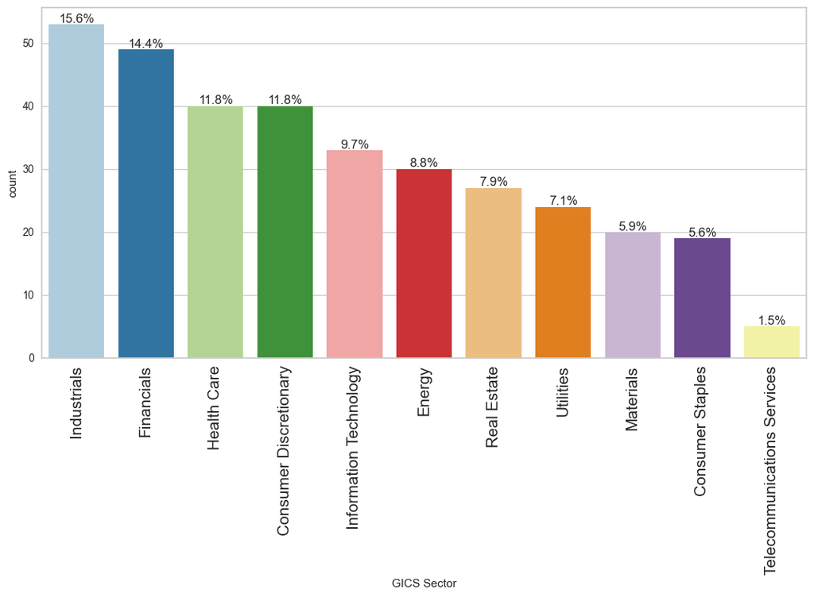

```python
labeled_barplot(df, 'GICS Sector', perc=True)
```

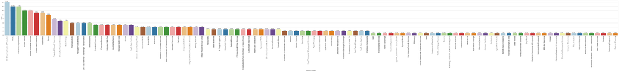

```python
labeled_barplot(df, 'GICS Sub Industry', perc=True)
```

```python
# function to plot a boxplot and a histogram along the same scale.


def histogram_boxplot(data, feature, figsize=(12, 7), kde=False, bins=None):
    """
    Boxplot and histogram combined

    data: dataframe
    feature: dataframe column
    figsize: size of figure (default (12,7))
    kde: whether to the show density curve (default False)
    bins: number of bins for histogram (default None)
    """
    f2, (ax_box2, ax_hist2) = plt.subplots(
        nrows=2,  # Number of rows of the subplot grid= 2
        sharex=True,  # x-axis will be shared among all subplots
        gridspec_kw={"height_ratios": (0.25, 0.75)},
        figsize=figsize,
    )  # creating the 2 subplots
    sns.boxplot(
        data=data, x=feature, ax=ax_box2, showmeans=True
    )  # boxplot will be created and a star will indicate the mean value of the column
    sns.histplot(
        data=data, x=feature, kde=kde, ax=ax_hist2, bins=bins
    ) if bins else sns.histplot(
        data=data, x=feature, kde=kde, ax=ax_hist2
    )  # For histogram
    ax_hist2.axvline(
        data[feature].mean(), linestyle="--"
    )  # Add mean to the histogram
    ax_hist2.axvline(
        data[feature].median(), linestyle="-"
    )  # Add median to the histogram
```

```python
num_col = ['Current Price', 'Price Change', 'Volatility', 'ROE', 'Cash Ratio', 'Net Cash Flow', 'Net Income', 'Earnings Per Share', 'P/E Ratio', 'P/B Ratio']
```

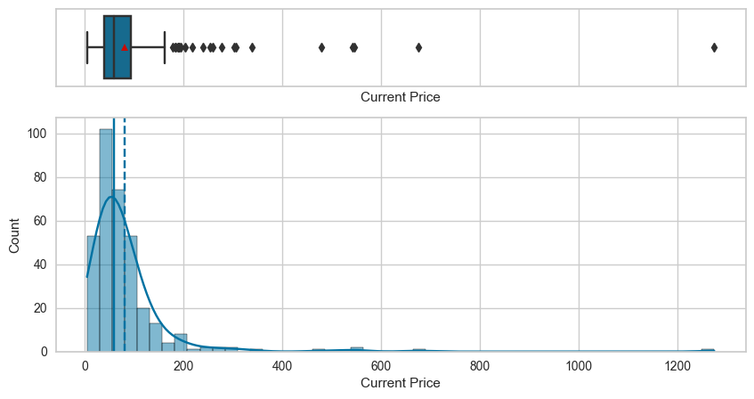

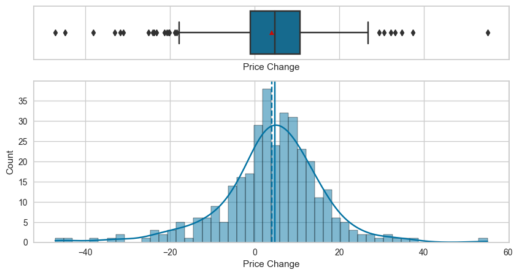

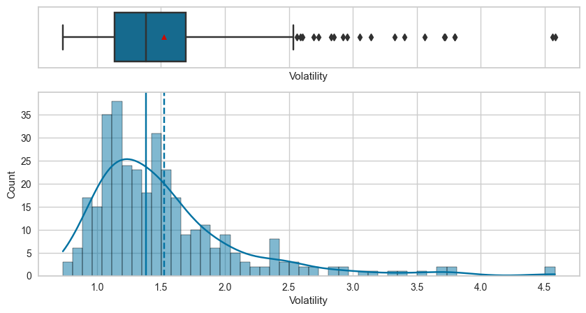

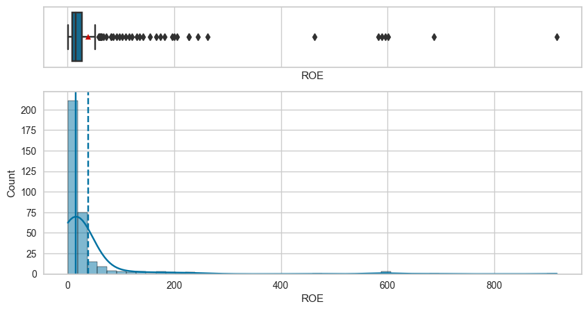

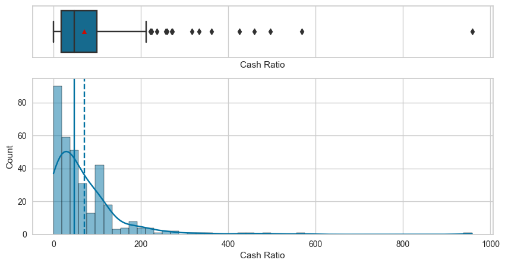

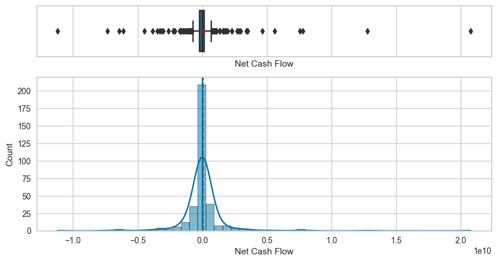

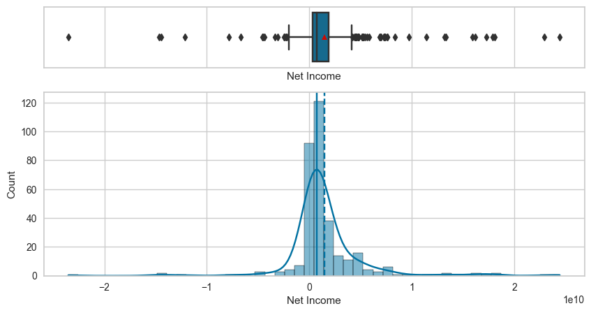

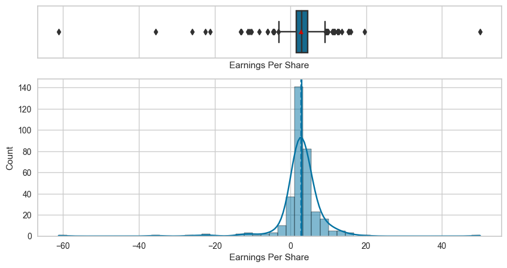

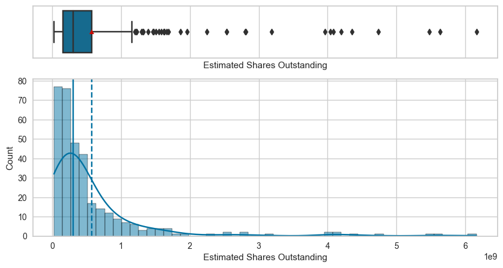

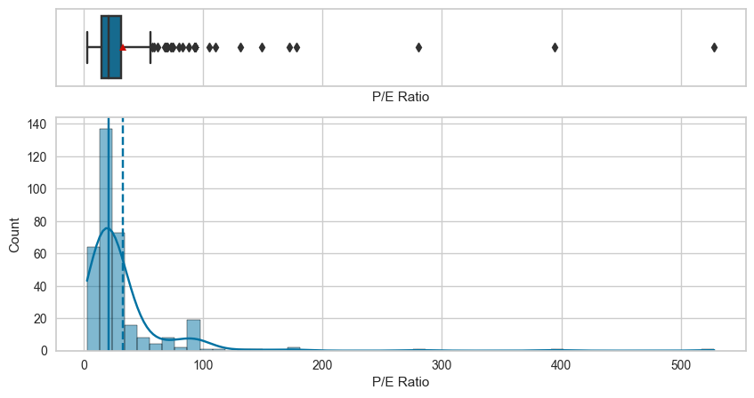

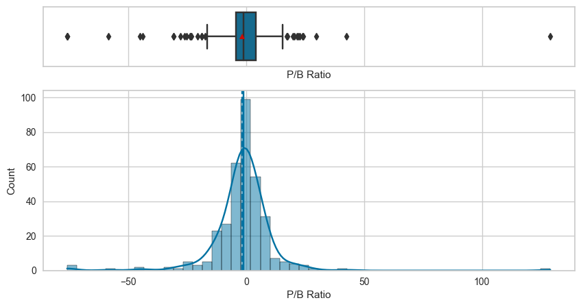

```python
for item in num_cols:
    histogram_boxplot(df, item, bins=50, kde=True, figsize=(10, 5))
```

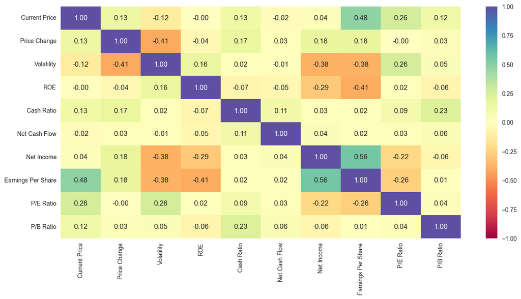

```python
plt.figure(figsize=(15, 7))
sns.heatmap(df[num_col].corr(), annot=True, vmin=-1, vmax=1, fmt=".2f", cmap="Spectral")
plt.show()
```

Earnings Per Share and Current Price are correlated along with Net Income and Earnings Per Share. P/E Ratio is less coreelated with Current Price.

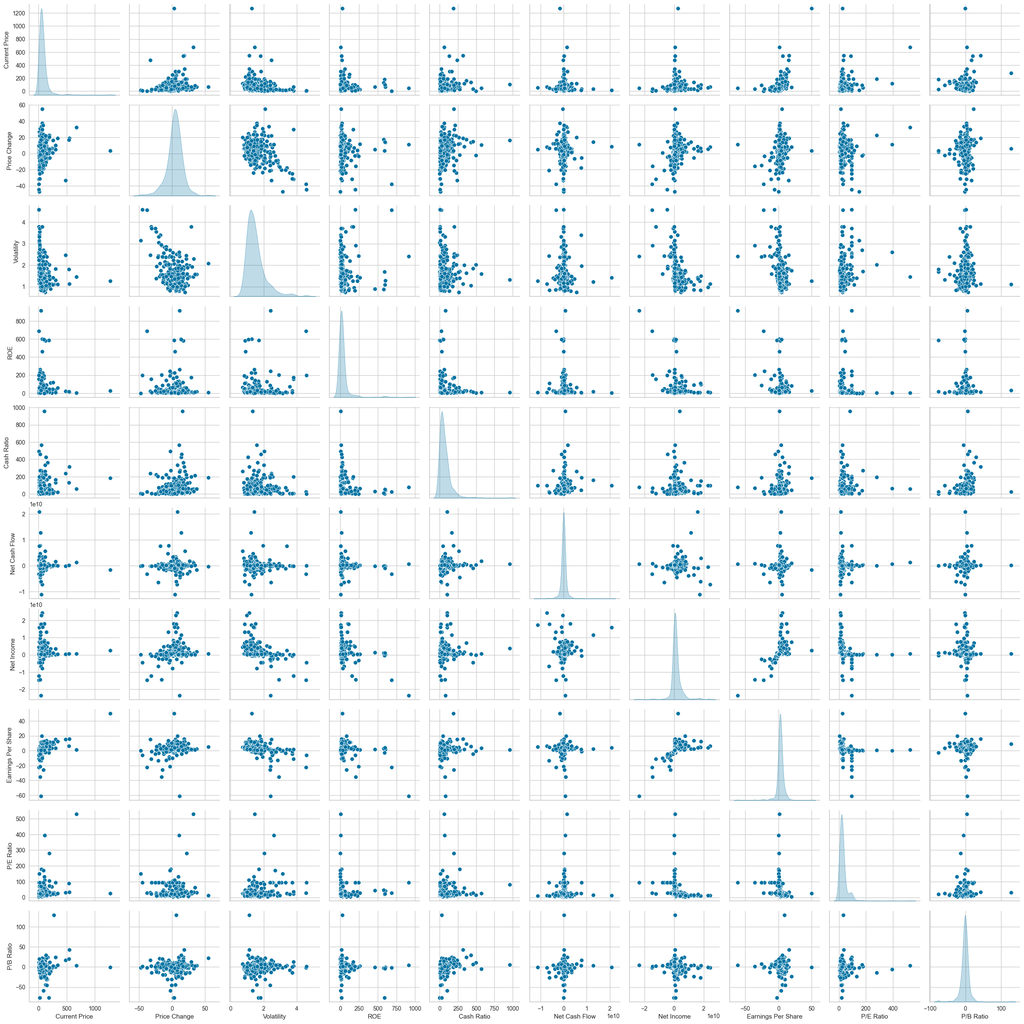

```python
sns.pairplot(data=df[num_col], diag_kind="kde")
plt.show()
```

Current Price is right skewed, Price change is normally distributed along with Net Cash Flow, and Net Income, Earnings Per Share, and P/b Ratio. The rest of the variables appear to be right skewed.

**Questions**:

1. What does the distribution of stock prices look like?
2. The stocks of which economic sector have seen the maximum price increase on average?
3. How are the different variables correlated with each other?
4. Cash ratio provides a measure of a company's ability to cover its short-term obligations using only cash and cash equivalents. How does the average cash ratio vary across economic sectors?
5. P/E ratios can help determine the relative value of a company's shares as they signify the amount of money an investor is willing to invest in a single share of a company per dollar of its earnings. How does the P/E ratio vary, on average, across economic sectors?

```python
print('Question 1: What does the distribution of stock prices look like?')
print("Distribution of Stock Prices:")
print(df['Current Price'].describe())
print()

print('Question 2: The stocks of which economic sector have seen the maximum price increase on average?')
max_price_increase_sector = df.groupby('GICS Sector')['Price Change'].mean().idxmax()
max_price_increase_mean = df.groupby('GICS Sector')['Price Change'].mean().max()
print(f"The sector with the maximum price increase on average is: {max_price_increase_sector}")
print(f"The maximum price increase on average is: {max_price_increase_mean:.2f}")
print()

print('Question 3: How are the different variables correlated with each other?')
correlation_matrix = df.corr()
print("Correlation Matrix:")
print(correlation_matrix)
print()

print('Question 4: How does the average cash ratio vary across economic sectors?')
average_cash_ratio_by_sector = df.groupby('GICS Sector')['Cash Ratio'].mean()
print("Average Cash Ratio Across Economic Sectors:")
print(average_cash_ratio_by_sector)
print()

print('Question 5: How does the P/E ratio vary, on average, across economic sectors?')
average_pe_ratio_by_sector = df.groupby('GICS Sector')['P/E Ratio'].mean()
print("Average P/E Ratio Across Economic Sectors:")
print(average_pe_ratio_by_sector)
```

```
Question 1: What does the distribution of stock prices look like?
Distribution of Stock Prices:
count     340.000000
mean       80.862345
std        98.055086
min         4.500000
25%        38.555000
50%        59.705000
75%        92.880001
max      1274.949951
Name: Current Price, dtype: float64

Question 2: The stocks of which economic sector have seen the maximum price increase on average?
The sector with the maximum price increase on average is: Health Care
The maximum price increase on average is: 9.59

Question 3: How are the different variables correlated with each other?
Correlation Matrix:
                              Current Price  Price Change  Volatility  \
Current Price                      1.000000      0.134982   -0.124257
Price Change                       0.134982      1.000000   -0.408281
Volatility                        -0.124257     -0.408281    1.000000
ROE                               -0.000549     -0.043310    0.162532
Cash Ratio                         0.127816      0.168586    0.020605
Net Cash Flow                     -0.021961      0.026746   -0.014172
Net Income                         0.036625      0.179298   -0.383433
Earnings Per Share                 0.479604      0.175401   -0.379309
Estimated Shares Outstanding      -0.145306      0.033656   -0.095704
P/E Ratio                          0.260273     -0.002491    0.263600
P/B Ratio                          0.124634      0.034329    0.046528

                                   ROE  Cash Ratio  Net Cash Flow  Net Income  \
Current Price                -0.000549    0.127816      -0.021961    0.036625
Price Change                 -0.043310    0.168586       0.026746    0.179298
Volatility                    0.162532    0.020605      -0.014172   -0.383433
ROE                           1.000000   -0.069122      -0.052205   -0.288524
Cash Ratio                   -0.069122    1.000000       0.113819    0.028589
Net Cash Flow                -0.052205    0.113819       1.000000    0.044229
Net Income                   -0.288524    0.028589       0.044229    1.000000
Earnings Per Share           -0.405291    0.024759       0.019348    0.557752
```

[output cut: 59 more lines]

```
Question 5: How does the P/E ratio vary, on average, across economic sectors?
Average P/E Ratio Across Economic Sectors:
GICS Sector
Consumer Discretionary         35.211613
Consumer Staples               25.521195
Energy                         72.897709
Financials                     16.023151
Health Care                    41.135272
Industrials                    18.259380
Information Technology         43.782546
Materials                      24.585352
Real Estate                    43.065585
Telecommunications Services    12.222578
Utilities                      18.719412
Name: P/E Ratio, dtype: float64
```

## Data Preprocessing

- Duplicate value check
- Missing value treatment
- Outlier check
- Feature engineering (if needed)
- Any other preprocessing steps (if needed)

```python
# Scaling the data set before clustering
scaler = StandardScaler()
subset = df[num_col].copy()
subset_scaled = scaler.fit_transform(subset)
```

```python
# Creating a dataframe from the scaled data
subset_scaled_df = pd.DataFrame(subset_scaled, columns=subset.columns)
```

## EDA

- It is a good idea to explore the data once again after manipulating it.

```python
subset_scaled_df.head()
```

|  | Current Price | Price Change | Volatility | ROE | Cash Ratio | Net Cash Flow | Net Income | Earnings Per Share | P/E Ratio | P/B Ratio |
| --- | --- | --- | --- | --- | --- | --- | --- | --- | --- | --- |
| 0 | -0.393341 | 0.493950 | 0.272749 | 0.989601 | -0.210698 | -0.339355 | 1.554415 | 1.309399 | -0.652487 | -0.506653 |
| 1 | -0.220837 | 0.355439 | 1.137045 | 0.937737 | 0.077269 | -0.002335 | 0.927628 | 0.056755 | -0.311769 | -0.504205 |
| 2 | -0.367195 | 0.602479 | -0.427007 | -0.192905 | -0.033488 | 0.454058 | 0.744371 | 0.024831 | -0.391502 | 0.094941 |
| 3 | 0.133567 | 0.825696 | -0.284802 | -0.317379 | 1.218059 | -0.152497 | -0.219816 | -0.230563 | 0.947148 | 0.424333 |
| 4 | -0.260874 | -0.492636 | 0.296470 | -0.265515 | 2.237018 | 0.133564 | -0.202703 | -0.374982 | 3.293307 | 0.199196 |

## K-means Clustering

```
Number of Clusters: 1 	Average Distortion: 2.408059969767462
Number of Clusters: 2 	Average Distortion: 2.247891340921506
Number of Clusters: 3 	Average Distortion: 2.232518116892162
Number of Clusters: 4 	Average Distortion: 2.0934576705241303
Number of Clusters: 5 	Average Distortion: 2.0485040877033733
Number of Clusters: 6 	Average Distortion: 1.9897120537023352
Number of Clusters: 7 	Average Distortion: 1.9501033369362621
Number of Clusters: 8 	Average Distortion: 1.871829650864594
```

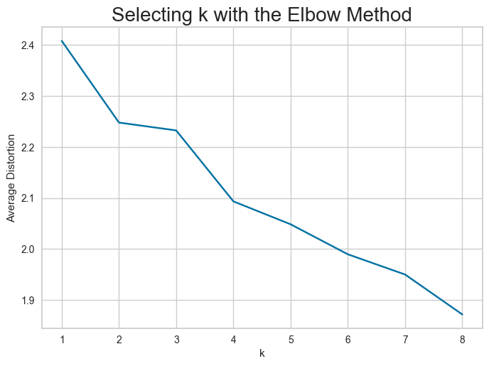

```python
import warnings

# Suppress UserWarning from scikit-learn
warnings.filterwarnings("ignore", category=UserWarning)


from sklearn.cluster import MiniBatchKMeans

clusters = range(1, 9)
meanDistortions = []

for k in clusters:
    model = MiniBatchKMeans(n_clusters=k, batch_size=4096)
    model.fit(subset_scaled_df)
    distortion = (
        sum(
            np.min(cdist(subset_scaled_df, model.cluster_centers_, "euclidean"), axis=1)
        )
        / subset_scaled_df.shape[0]
    )

    meanDistortions.append(distortion)

    print("Number of Clusters:", k, "\tAverage Distortion:", distortion)

plt.plot(clusters, meanDistortions, "bx-")
plt.xlabel("k")
plt.ylabel("Average Distortion")
plt.title("Selecting k with the Elbow Method", fontsize=20)
```

```
For n_clusters = 2, silhouette score is 0.4597458508492653
For n_clusters = 3, silhouette score is 0.4663054501639373
For n_clusters = 4, silhouette score is 0.41128495450116326
For n_clusters = 5, silhouette score is 0.40768769783925896
For n_clusters = 6, silhouette score is 0.34004878652708004
For n_clusters = 7, silhouette score is 0.4166293647196123
For n_clusters = 8, silhouette score is 0.34309175882062826
For n_clusters = 9, silhouette score is 0.11549982113800135
```

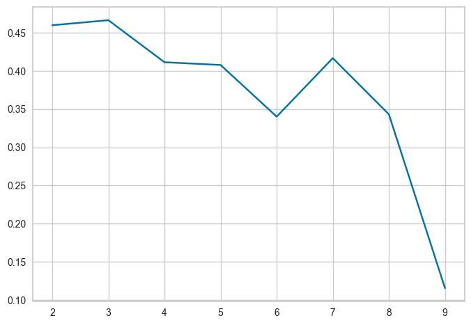

```python
sil_score = []
cluster_list = list(range(2, 10))
for n_clusters in cluster_list:
    clusterer = KMeans(n_clusters=n_clusters)
    preds = clusterer.fit_predict((subset_scaled_df))
    # centers = clusterer.cluster_centers_
    score = silhouette_score(subset_scaled_df, preds)
    sil_score.append(score)
    print("For n_clusters = {}, silhouette score is {}".format(n_clusters, score))

plt.plot(cluster_list, sil_score)
```

it appears based on the silloute scores that 2 or 3 clusters should be used.

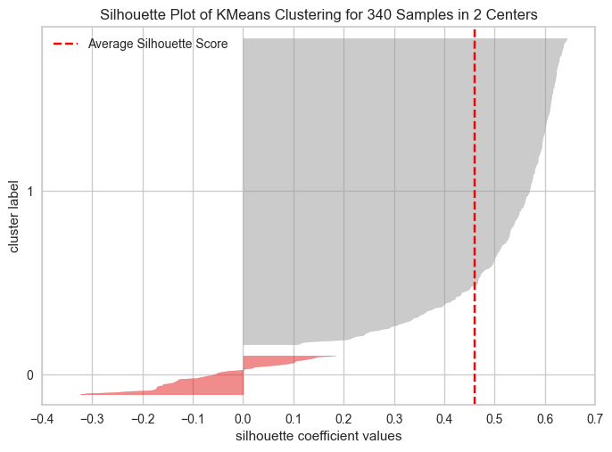

```python
# finding optimal no. of clusters with silhouette coefficients
visualizer = SilhouetteVisualizer(KMeans(2, random_state=1))
visualizer.fit(subset_scaled_df)
visualizer.show()
```

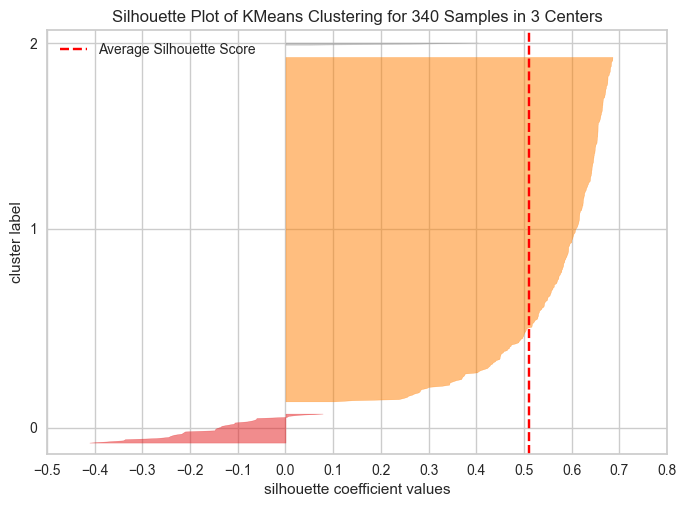

```python
# finding optimal no. of clusters with silhouette coefficients
visualizer = SilhouetteVisualizer(KMeans(3, random_state=1))
visualizer.fit(subset_scaled_df)
visualizer.show()
```

```python
kmeans = KMeans(n_clusters=3, random_state=0)
kmeans.fit(subset_scaled_df)
```

```
KMeans(n_clusters=3, random_state=0)
```

```python
# adding kmeans cluster labels to the original dataframe
subset_scaled_df["K_means_segments"] = kmeans.labels_
```

```python
cluster_profile = subset_scaled_df.groupby("K_means_segments").mean()
```

```python
cluster_profile["count_in_each_segment"] = (
    subset_scaled_df.groupby("K_means_segments")["Current Price"].count().values
)
```

```python
# let's display cluster profiles
cluster_profile.style.highlight_max(color="lightgreen", axis=0)
```

| K_means_segments | Current Price | Price Change | Volatility | ROE | Cash Ratio | Net Cash Flow | Net Income | Earnings Per Share | P/E Ratio | P/B Ratio | count_in_each_segment |
| --- | --- | --- | --- | --- | --- | --- | --- | --- | --- | --- | --- |
| 0 | -0.115136 | -0.016489 | -0.106487 | -0.062071 | -0.185532 | -0.071316 | 0.069408 | 0.069876 | -0.129645 | -0.099154 | 305 |
| 1 | 1.444936 | 0.772602 | 0.368556 | -0.155255 | 2.164821 | 0.968401 | 0.098934 | 0.444012 | 1.172739 | 1.074776 | 27 |
| 2 | -0.487087 | -1.978880 | 2.815954 | 2.890427 | -0.232849 | -0.549445 | -2.980066 | -4.162559 | 0.984722 | 0.152884 | 8 |

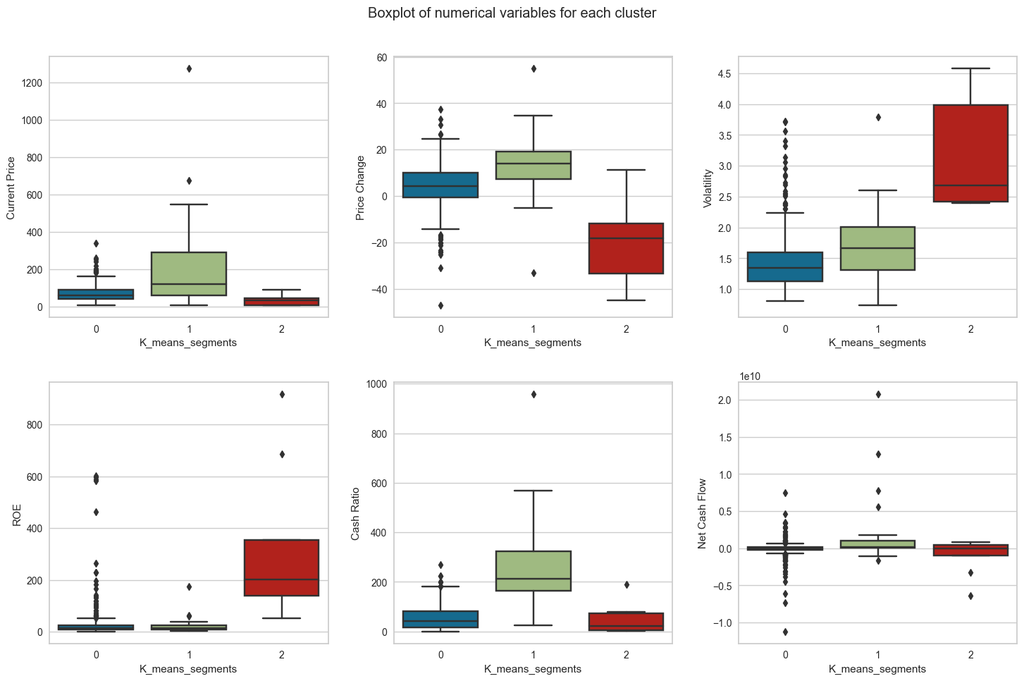

```python
plt.figure(figsize=(15, 10))
plt.suptitle("Boxplot of numerical variables for each cluster")

for i, variable in enumerate(num_col[:6]):
    plt.subplot(2, 3, i +1)
    sns.boxplot(data=df, x="K_means_segments", y=variable)

plt.tight_layout(pad=2.0)
```

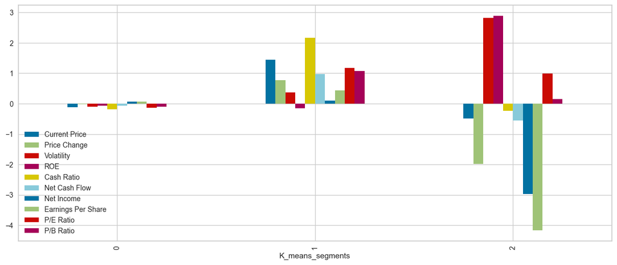

```python
subset_scaled_df.groupby("K_means_segments").mean().plot.bar(figsize=(15, 6))
```

Cluster 1:

- Current Price is moderate when all other variables are low to moderate.

Cluster 2:

- Current price is high when price change, Cash Ratio, Net Cash Flow, P/E Ratio and P/B Ratio are high, whil Volatility is moderate and ROE is low.

Cluster 3:

- Current Price is low when Price Change is low, Volatiilty is high and ROE is high, yet Net Income is very low and Earnings Per Share is very low.

## Hierarchical Clustering

```python
# list of distance metrics
distance_metrics = ["euclidean", "chebyshev", "mahalanobis", "cityblock"]

# list of linkage methods
linkage_methods = ["single", "complete", "average", "weighted"]

high_cophenet_corr = 0
high_dm_lm = [0, 0]

for dm in distance_metrics:
    for lm in linkage_methods:
        Z = linkage(subset_scaled_df, metric=dm, method=lm)
        c, coph_dists = cophenet(Z, pdist(subset_scaled_df))
        print(
            "Cophenetic correlation for {} distance and {} linkage is {}.".format(
                dm.capitalize(), lm, c
            )
        )
        if high_cophenet_corr < c:
            high_cophenet_corr = c
            high_dm_lm[0] = dm
            high_dm_lm[1] = lm
```

```
Cophenetic correlation for Euclidean distance and single linkage is 0.9275092027422666.
Cophenetic correlation for Euclidean distance and complete linkage is 0.7659247343987279.
Cophenetic correlation for Euclidean distance and average linkage is 0.9343521403355429.
Cophenetic correlation for Euclidean distance and weighted linkage is 0.8278195856856951.
Cophenetic correlation for Chebyshev distance and single linkage is 0.9158253573957323.
Cophenetic correlation for Chebyshev distance and complete linkage is 0.7895759808565844.
Cophenetic correlation for Chebyshev distance and average linkage is 0.926641210140557.
Cophenetic correlation for Chebyshev distance and weighted linkage is 0.896761182991931.
Cophenetic correlation for Mahalanobis distance and single linkage is 0.9170231412492253.
Cophenetic correlation for Mahalanobis distance and complete linkage is 0.8389960556324773.
Cophenetic correlation for Mahalanobis distance and average linkage is 0.9300121300251174.
Cophenetic correlation for Mahalanobis distance and weighted linkage is 0.8895232937064912.
Cophenetic correlation for Cityblock distance and single linkage is 0.923238172114725.
Cophenetic correlation for Cityblock distance and complete linkage is 0.6691631144394278.
Cophenetic correlation for Cityblock distance and average linkage is 0.9084607520325577.
Cophenetic correlation for Cityblock distance and weighted linkage is 0.7875455226273046.
```

```python
# printing the combination of distance metric and linkage method with the highest cophenetic correlation
print(
    "Highest cophenetic correlation is {}, which is obtained with {} distance and {} linkage.".format(
        high_cophenet_corr, high_dm_lm[0].capitalize(), high_dm_lm[1]
    )
)
```

```
Highest cophenetic correlation is 0.9343521403355429, which is obtained with Euclidean distance and average linkage.
```

```python
# list of linkage methods
linkage_methods = ["single", "complete", "average", "centroid", "ward", "weighted"]

high_cophenet_corr = 0
high_dm_lm = [0, 0]

for lm in linkage_methods:
    Z = linkage(subset_scaled_df, metric="euclidean", method=lm)
    c, coph_dists = cophenet(Z, pdist(subset_scaled_df))
    print("Cophenetic correlation for {} linkage is {}.".format(lm, c))
    if high_cophenet_corr < c:
        high_cophenet_corr = c
        high_dm_lm[0] = "euclidean"
        high_dm_lm[1] = lm
```

```
Cophenetic correlation for single linkage is 0.9275092027422666.
Cophenetic correlation for complete linkage is 0.7659247343987279.
Cophenetic correlation for average linkage is 0.9343521403355429.
Cophenetic correlation for centroid linkage is 0.936907151305329.
Cophenetic correlation for ward linkage is 0.5945938833308497.
Cophenetic correlation for weighted linkage is 0.8278195856856951.
```

```python
# printing the combination of distance metric and linkage method with the highest cophenetic correlation
print(
    "Highest cophenetic correlation is {}, which is obtained with {} linkage.".format(
        high_cophenet_corr, high_dm_lm[1]
    )
)
```

```
Highest cophenetic correlation is 0.936907151305329, which is obtained with centroid linkage.
```

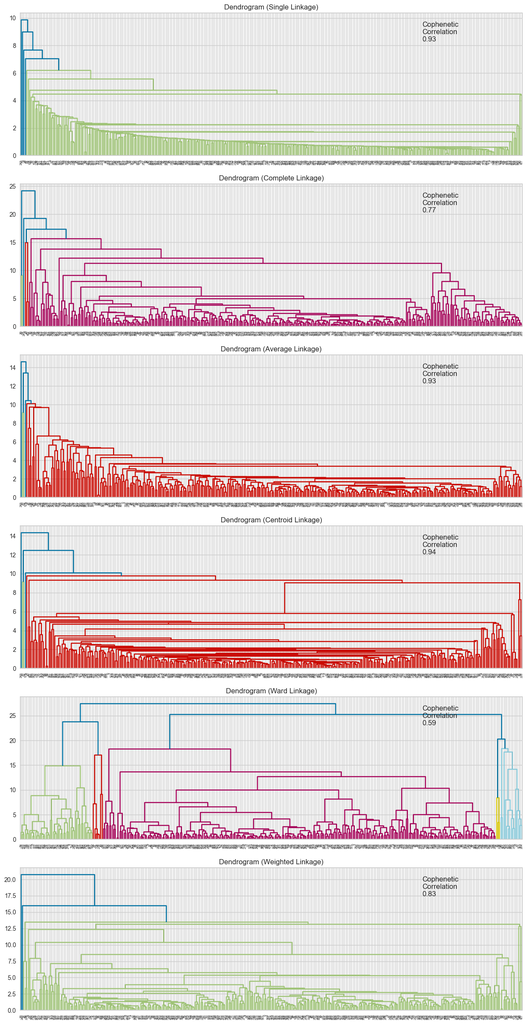

```python
# list of linkage methods
linkage_methods = ["single", "complete", "average", "centroid", "ward", "weighted"]

# lists to save results of cophenetic correlation calculation
compare_cols = ["Linkage", "Cophenetic Coefficient"]

# to create a subplot image
fig, axs = plt.subplots(len(linkage_methods), 1, figsize=(15, 30))

# We will enumerate through the list of linkage methods above
# For each linkage method, we will plot the dendrogram and calculate the cophenetic correlation
for i, method in enumerate(linkage_methods):
    Z = linkage(subset_scaled_df, metric="euclidean", method=method)

    dendrogram(Z, ax=axs[i])
    axs[i].set_title(f"Dendrogram ({method.capitalize()} Linkage)")

    coph_corr, coph_dist = cophenet(Z, pdist(subset_scaled_df))
    axs[i].annotate(
        f"Cophenetic\nCorrelation\n{coph_corr:0.2f}",
        (0.80, 0.80),
        xycoords="axes fraction",
    )
```

```python
HCmodel = AgglomerativeClustering(n_clusters=8, linkage="single")
HCmodel.fit(subset_scaled_df)
```

```
AgglomerativeClustering(linkage='single', n_clusters=8)
```

```python
subset_scaled_df["HC_Clusters"] = HCmodel.labels_
df["HC_Clusters"] = HCmodel.labels_
```

```python
cluster_profile = subset_scaled_df.groupby("HC_Clusters").mean()
```

```python
cluster_profile["count_in_each_segments"] = (
    subset_scaled_df.groupby("HC_Clusters")["Price Change"].count().values
)
```

```python
# lets display cluster profile
cluster_profile.style.highlight_max(color="lightgreen", axis=0)
```

| HC_Clusters | Current Price | Price Change | Volatility | ROE | Cash Ratio | Net Cash Flow | Net Income | Earnings Per Share | P/E Ratio | P/B Ratio | K_means_segments | count_in_each_segments |
| --- | --- | --- | --- | --- | --- | --- | --- | --- | --- | --- | --- | --- |
| 0 | 0.280272 | 0.555489 | -0.609690 | 5.462377 | -0.480943 | -0.172008 | -0.205168 | -0.186781 | 0.051630 | -1.085094 | 0.000000 | 5 |
| 1 | -0.059126 | -0.010724 | -0.005017 | -0.128011 | 0.002610 | -0.044894 | 0.016783 | 0.019624 | -0.035558 | -0.016270 | 0.103659 | 328 |
| 2 | -0.564007 | 0.597207 | -0.344579 | -0.281074 | 0.669815 | 8.592722 | 3.090627 | 0.078798 | -0.428216 | 0.231367 | 1.000000 | 2 |
| 3 | 12.195670 | -0.074042 | -0.435986 | -0.109922 | 1.262362 | -0.888563 | 0.268653 | 7.192572 | -0.161672 | 0.047742 | 1.000000 | 1 |
| 4 | 1.998837 | 0.176091 | -0.692132 | -0.099549 | -0.498664 | 0.018187 | -0.228206 | 0.932390 | -0.035502 | 9.377562 | 1.000000 | 1 |
| 5 | 6.077244 | 2.351380 | -0.110995 | -0.369243 | -0.133168 | 0.657300 | -0.228344 | -0.227522 | 11.187619 | 0.403165 | 1.000000 | 1 |
| 6 | -0.371689 | 0.610544 | 1.488223 | 9.101176 | 0.110496 | 0.330570 | -6.359977 | -9.725729 | 1.365673 | 0.479628 | 2.000000 | 1 |
| 7 | -0.779918 | -3.518321 | 5.134029 | 6.715418 | -0.531891 | -1.717796 | -4.112338 | -3.831916 | -0.094948 | -0.008768 | 2.000000 | 1 |

[figure not shown]

```python
plt.figure(figsize=(20, 35))
plt.suptitle("Boxplot of scaled numerical variables for each cluster", fontsize=20)

for i, variable in enumerate(num_cols[:6]):
    plt.subplot(5, 3, i + 1)
    sns.boxplot(data=subset_scaled_df, x="HC_Clusters", y=variable)

plt.tight_layout(pad=2.0)
```

Cluster 1 has the most stocks listed with moderate current price and volatility. Cluster 3 has only one stock listed and is an outlier with the highest current price and cash ratio. Cluster 2 appears to have the highest net cash flow and net income.

## K-means vs Hierarchical Clustering

You compare several things, like:

- Which clustering technique took less time for execution?
- Which clustering technique gave you more distinct clusters, or are they the same?
- How many observations are there in the similar clusters of both algorithms?
- How many clusters are obtained as the appropriate number of clusters from both algorithms?

You can also mention any differences or similarities you obtained in the cluster profiles from both the clustering techniques.

Both methods appear to cluster the majority of stocks into one group. K-means clustering appears to be more clean on identyfing stocks that are outliers. Hierarchicial clustering gave more unique clusters compared to K-means.

## Actionable Insights and Recommendations

It would appear that the K-means clusters could be utilized to identify potential stocks that are stable (cluster 0) or stocks that need to be looked further into as potential good investments (cluster 1). stocks that are placed into cluster 2 could be identified as stocks that are trending down and should not be invested into, or potentially dropped as investments (but it would be wise to look further into these for potential rebounds).

It's important to not take clustering of these groups as the sole reason to invest in a stock because there are many other variables that are not being accounted for like media sentiment of the company in question, or upcoming earnings reports. These clustering methods should only be used to comb through a large amount of stocks to then look further into the companies.